# BA636_Project_Hien Do & Khanh Dang

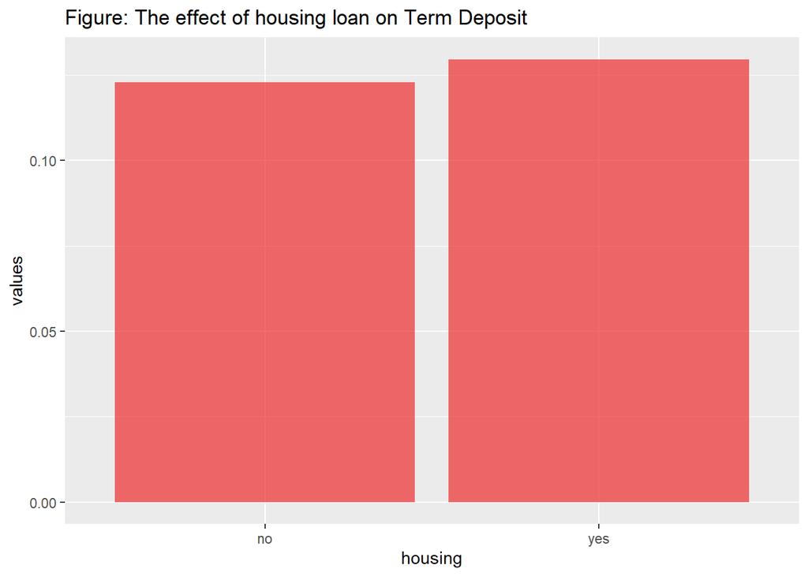

```r
housingloan.agg<-aggregate(bank.df2$y=="yes", by=list(bank.df2$housing), mean)
names(housingloan.agg)<-c("housing", "values")
ggplot(data = housingloan.agg, mapping = aes(x=housing, y=values)) + geom_col(fill="firebrick2", alpha=0.7) + ggtitle("Figure: The effect of housing loan on Term Deposit")
```

**The effect of personal loan on Term deposit decision**

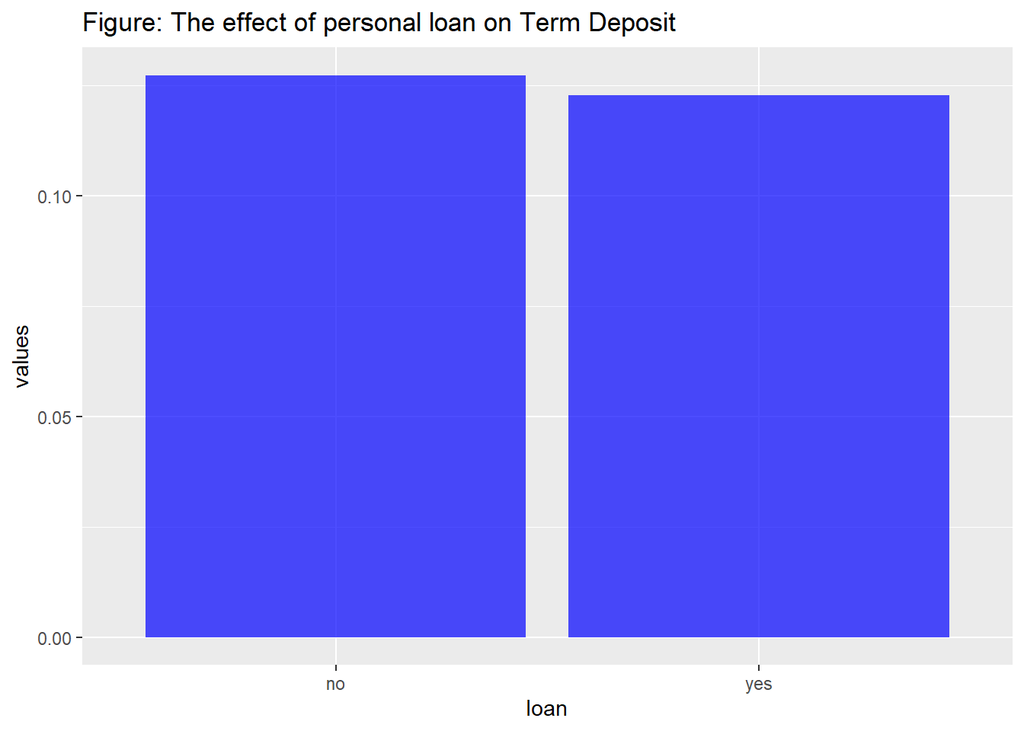

```r
loan.agg<-aggregate(bank.df2$y=="yes", by=list(bank.df2$loan), mean)
names(loan.agg)<-c("loan", "values")
ggplot(data = loan.agg, mapping = aes(x=loan, y=values)) + geom_col(fill="blue", alpha=0.7) + ggtitle("Figure: The effect of personal loan on Term Deposit")
```

**The effect of contact type on Term deposit decision**

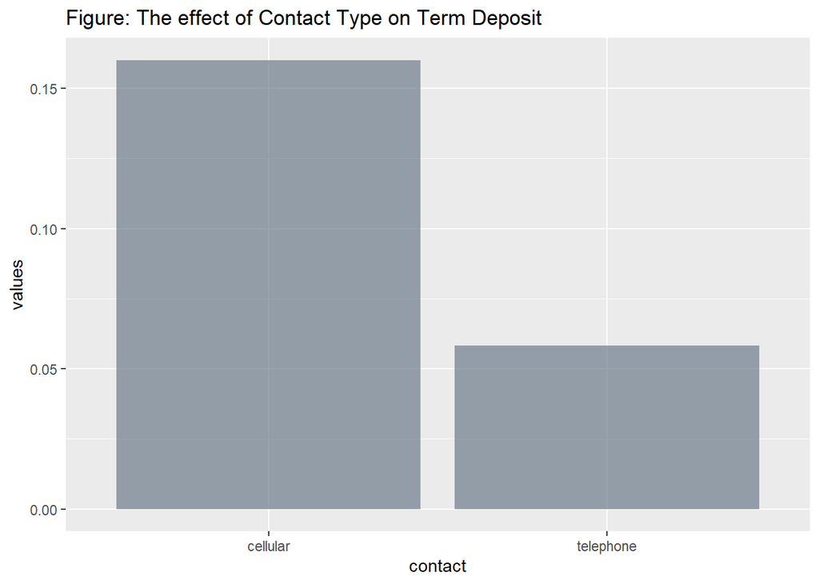

```r
contact.agg<-aggregate(bank.df2$y=="yes", by=list(bank.df2$contact), mean)
names(contact.agg)<-c("contact", "values")
ggplot(data = contact.agg, mapping = aes(x=contact, y=values)) + geom_col(fill="slategray4", alpha=0.7) + ggtitle("Figure: The effect of Contact Type on Term Deposit")
```

**The effect of month on Term deposit decision**

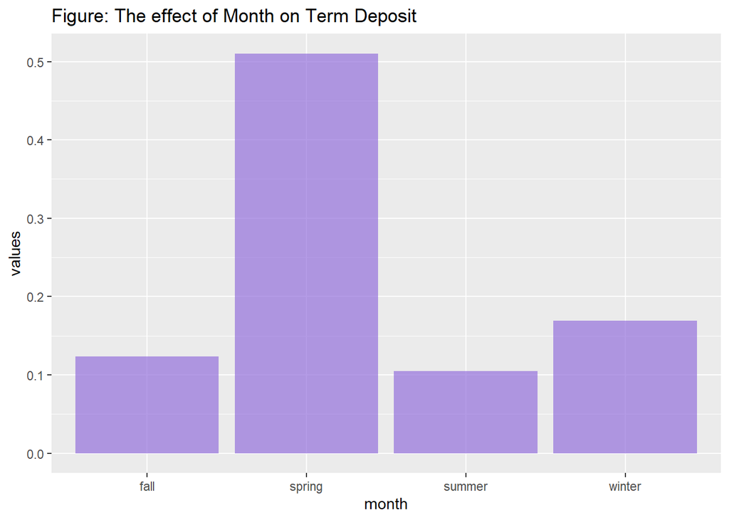

```r
month.agg<-aggregate(bank.df2$y=="yes", by=list(bank.df2$month), mean)
names(month.agg)<-c("month", "values")
ggplot(data=month.agg, mapping = aes(x=month, y=values)) + geom_col(fill="mediumpurple", alpha=0.7) + ggtitle("Figure: The effect of Month on Term Deposit")
```

**The effect of day of week on Term deposit decision**

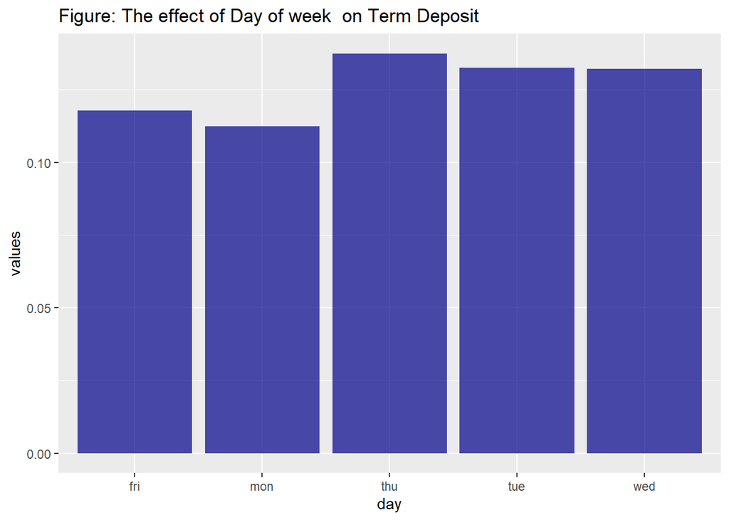

```r
day.agg<-aggregate(bank.df2$y=="yes", by=list(bank.df2$day_of_week), mean)
names(day.agg)<-c("day", "values")
ggplot(data=day.agg, mapping = aes(x=day, y=values)) + geom_col(fill="blue4", alpha=0.7) + ggtitle("Figure: The effect of Day of week  on Term Deposit")
```

**The effect of poutcome on Term deposit decision**

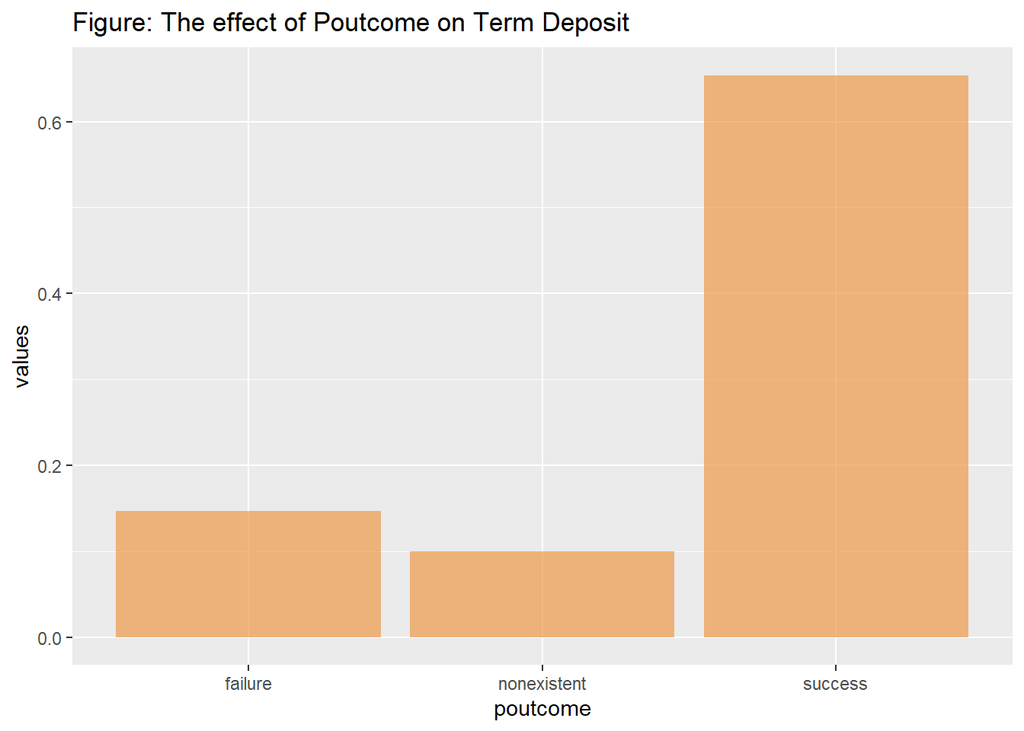

```r
poutcome.agg<-aggregate(bank.df2$y=="yes", by=list(bank.df2$poutcome), mean)
names(poutcome.agg)<-c("poutcome", "values")
ggplot(data=poutcome.agg, mapping = aes(x=poutcome, y=values)) + geom_col(fill="tan2", alpha=0.7) + ggtitle("Figure: The effect of Poutcome on Term Deposit")
```

**Checking correlation of job and education**

*By visualization*

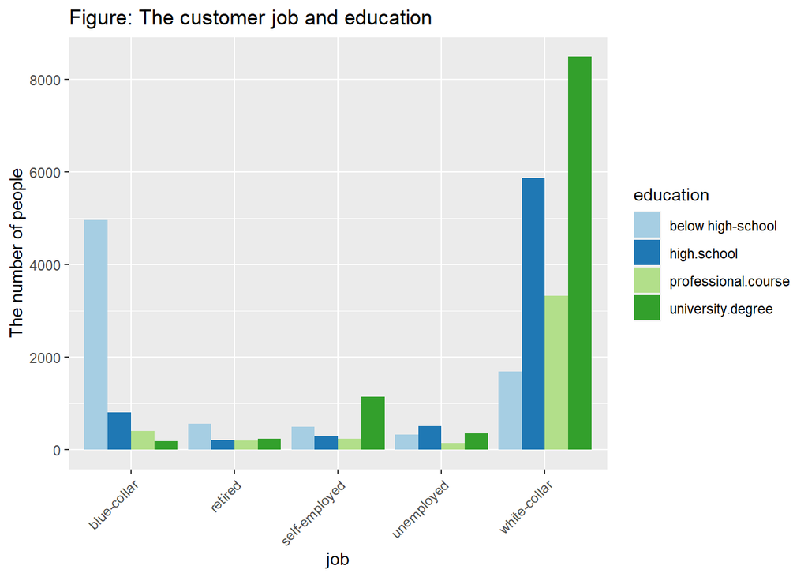

```r
job.edu<-group_by(bank.df2, job, education)
job.edu<-summarise(job.edu, n=n())
ggplot(job.edu, aes(x=job, y=n))+geom_col(aes(fill=education), position = "dodge")+theme(axis.text.x=element_text(angle=45, hjust =1))+
  scale_fill_brewer(palette="Paired")+ylab("The number of people")+ggtitle("Figure: The customer job and education")
```

*By correlation matrix*

```r
edu.job2<-bank.df2[,c(2,4)]
edu.job2$job<-ifelse(edu.job2$job=="retired",1,ifelse(edu.job2$job=="unemployed",2,ifelse(edu.job2$job=="blue-collar",3,ifelse(edu.job2$job=="self-employed",4,5))))
edu.job2$education<-ifelse(edu.job2$education=="below high school",1,ifelse(edu.job2$education=="high.school",2,ifelse(edu.job2$education=="university.degree",3,4)))
cor(edu.job2)%>%kable(caption = "Table: Correlation matrix of job and education")%>%kableExtra::kable_styling(bootstrap_options = "striped")
```

Table: Correlation matrix of job and education

|  | job | education |
| --- | --- | --- |
| job | 1.000000 | -0.286833 |
| education | -0.286833 | 1.000000 |

#### **Numerical variables**

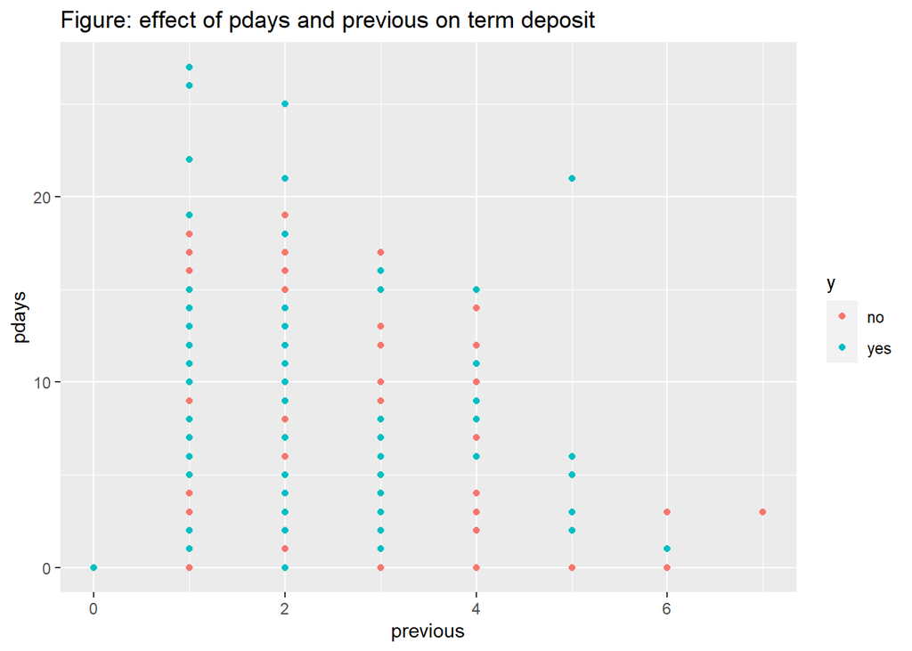

```r
ggplot(data=bank.df2, aes(y=pdays,x=previous, color=y)) + geom_point() + ggtitle("Figure: effect of pdays and previous on term deposit")
```

**Export bank.df2 for project update 4 and for cleaned data to submit**

```r
write_excel_csv(bank.df2, "C:/Users/kieuk/OneDrive/Documents/BA636 Data Mining/PROJECT/Project update/Cleaned banking data/cleaneddata.csv")
```

### **6. Oversampling and partitioning data into training and validation dataset**

```r
# Transforming term deposit into 0,1 y creating new variable
bank.df2<-mutate(bank.df2, isyes=ifelse(bank.df2$y=="yes",1,0))
#separate data
term.yes<-filter(bank.df2, y=="yes")
term.no<-filter(bank.df2, y=="no")
# partitioning data
set.seed(2)
train.yes.row<-sample(c(1:3859), dim(term.yes)*0.5)
train.yes<-term.yes[train.yes.row,]
valid.yes<-term.yes[-train.yes.row,]
train.no.row<-sample(c(1:26629), dim(term.yes)*0.5)
train.no<-term.no[train.no.row,]
training.bank.df<-rbind(train.yes, train.no)
valid.no.row<-sample(setdiff(rownames(term.no), train.no.row), 0.87*1930/0.13)
valid.no<-term.no[valid.no.row,]
validation.bank.df<-rbind(valid.yes, valid.no)
# Checking again
training.checking<-group_by(training.bank.df, y)
training.checking<-summarise(training.checking, count=n())
validation.checking<-group_by(validation.bank.df, y)
validation.checking<-summarise(validation.checking, count=n())
validation.checking<-mutate(validation.checking, percent=count/sum(count))
training.checking%>%kable(caption="Table: Checking training set after oversampling")%>%kableExtra::kable_styling(bootstrap_options = "striped")
```

Table: Checking training set after oversampling

| y | count |
| --- | --- |
| no | 1929 |
| yes | 1929 |

```r
validation.checking%>%kable(caption = "Table: Checking validation after oversampling")%>%kableExtra::kable_styling(bootstrap_options = "striped")
```

Table: Checking validation after oversampling

| y | count | percent |
| --- | --- | --- |
| no | 12916 | 0.8699987 |
| yes | 1930 | 0.1300013 |

### **7. Building logistic regression model on training dataset**

#### **Model 1: All predictors as I mentioned above except for emp.var.rate to avoid multicollinearity**

**Original model**

```r
mod1<-glm(isyes~job + marital + education + contact+ month + poutcome + duration + campaign+ euribor3m+nr.employed, data = training.bank.df, family = binomial(link="logit"))
summary(mod1)
```

```
##
## Call:
## glm(formula = isyes ~ job + marital + education + contact + month +
##     poutcome + duration + campaign + euribor3m + nr.employed,
##     family = binomial(link = "logit"), data = training.bank.df)
##
## Deviance Residuals:
##     Min       1Q   Median       3Q      Max
## -4.6789  -0.4467  -0.0393   0.5162   2.6293
##
## Coefficients:
##                                Estimate Std. Error z value Pr(>|z|)
## (Intercept)                  41.0273569 10.3137954   3.978 6.95e-05 ***
## jobretired                    0.9003761  0.2389761   3.768 0.000165 ***
## jobself-employed              0.1161457  0.2497710   0.465 0.641925
## jobunemployed                 0.8284860  0.2439021   3.397 0.000682 ***
## jobwhite-collar               0.3675018  0.1677184   2.191 0.028439 *
## maritalmarried                0.2148441  0.1615138   1.330 0.183456
## maritalsingle                 0.1729318  0.1709028   1.012 0.311599
## educationhigh.school          0.2602740  0.1633198   1.594 0.111015
## educationprofessional.course  0.0918134  0.1868440   0.491 0.623150
## educationuniversity.degree    0.3997840  0.1625421   2.460 0.013910 *
## contacttelephone              0.0711393  0.1532812   0.464 0.642569
## monthspring                   1.7111944  0.3517443   4.865 1.15e-06 ***
## monthsummer                  -0.8140802  0.1389171  -5.860 4.62e-09 ***
## monthwinter                   0.1073850  0.1603356   0.670 0.503016
## poutcomenonexistent           0.5337751  0.1465803   3.642 0.000271 ***
## poutcomesuccess               1.5860071  0.2270098   6.987 2.82e-12 ***
## duration                      0.0066401  0.0002516  26.391  < 2e-16 ***
## campaign                     -0.0205556  0.0269309  -0.763 0.445301
## euribor3m                    -0.4665060  0.1002583  -4.653 3.27e-06 ***
## nr.employed                  -0.0083812  0.0020595  -4.070 4.71e-05 ***
## ---
## Signif. codes:  0 '***' 0.001 '**' 0.01 '*' 0.05 '.' 0.1 ' ' 1
##
## (Dispersion parameter for binomial family taken to be 1)
##
##     Null deviance: 5348.3  on 3857  degrees of freedom
## Residual deviance: 2723.1  on 3838  degrees of freedom
## AIC: 2763.1
##
## Number of Fisher Scoring iterations: 6
```

**Model with forward selection**

```r
mod1.forward<-step(mod1,direction = "forward")
```

```
## Start:  AIC=2763.13
## isyes ~ job + marital + education + contact + month + poutcome +
##     duration + campaign + euribor3m + nr.employed
```

```r
summary(mod1.forward)
```

```
##
## Call:
## glm(formula = isyes ~ job + marital + education + contact + month +
##     poutcome + duration + campaign + euribor3m + nr.employed,
##     family = binomial(link = "logit"), data = training.bank.df)
##
## Deviance Residuals:
##     Min       1Q   Median       3Q      Max
## -4.6789  -0.4467  -0.0393   0.5162   2.6293
##
## Coefficients:
##                                Estimate Std. Error z value Pr(>|z|)
## (Intercept)                  41.0273569 10.3137954   3.978 6.95e-05 ***
## jobretired                    0.9003761  0.2389761   3.768 0.000165 ***
## jobself-employed              0.1161457  0.2497710   0.465 0.641925
## jobunemployed                 0.8284860  0.2439021   3.397 0.000682 ***
## jobwhite-collar               0.3675018  0.1677184   2.191 0.028439 *
## maritalmarried                0.2148441  0.1615138   1.330 0.183456
## maritalsingle                 0.1729318  0.1709028   1.012 0.311599
## educationhigh.school          0.2602740  0.1633198   1.594 0.111015
## educationprofessional.course  0.0918134  0.1868440   0.491 0.623150
## educationuniversity.degree    0.3997840  0.1625421   2.460 0.013910 *
## contacttelephone              0.0711393  0.1532812   0.464 0.642569
## monthspring                   1.7111944  0.3517443   4.865 1.15e-06 ***
## monthsummer                  -0.8140802  0.1389171  -5.860 4.62e-09 ***
## monthwinter                   0.1073850  0.1603356   0.670 0.503016
## poutcomenonexistent           0.5337751  0.1465803   3.642 0.000271 ***
## poutcomesuccess               1.5860071  0.2270098   6.987 2.82e-12 ***
## duration                      0.0066401  0.0002516  26.391  < 2e-16 ***
## campaign                     -0.0205556  0.0269309  -0.763 0.445301
## euribor3m                    -0.4665060  0.1002583  -4.653 3.27e-06 ***
## nr.employed                  -0.0083812  0.0020595  -4.070 4.71e-05 ***
## ---
## Signif. codes:  0 '***' 0.001 '**' 0.01 '*' 0.05 '.' 0.1 ' ' 1
##
## (Dispersion parameter for binomial family taken to be 1)
##
##     Null deviance: 5348.3  on 3857  degrees of freedom
## Residual deviance: 2723.1  on 3838  degrees of freedom
## AIC: 2763.1
##
## Number of Fisher Scoring iterations: 6
```

```r
accuracy(mod1.forward)
```

```
##                      ME      RMSE       MAE  MPE MAPE      MASE
## Training set 1.1655e-17 0.3250792 0.2160402 -Inf  Inf 0.4320803
```

**Model with backward elimination**

```r
mod1.backward<-step(mod1, direction="backward")
```

```
## Start:  AIC=2763.13
## isyes ~ job + marital + education + contact + month + poutcome +
##     duration + campaign + euribor3m + nr.employed
##
##               Df Deviance    AIC
## - marital      2   2724.9 2760.9
## - contact      1   2723.3 2761.3
## - campaign     1   2723.7 2761.7
## <none>             2723.1 2763.1
## - education    3   2730.9 2764.9
## - job          4   2745.5 2777.5
## - nr.employed  1   2740.3 2778.3
## - euribor3m    1   2744.7 2782.7
## - poutcome     2   2777.5 2813.5
## - month        3   2833.3 2867.3
## - duration     1   4184.5 4222.5
##
## Step:  AIC=2760.91
## isyes ~ job + education + contact + month + poutcome + duration +
##     campaign + euribor3m + nr.employed
##
##               Df Deviance    AIC
## - contact      1   2725.1 2759.1
## - campaign     1   2725.5 2759.5
## <none>             2724.9 2760.9
## - education    3   2732.4 2762.4
## - job          4   2746.7 2774.7
## - nr.employed  1   2742.3 2776.3
## - euribor3m    1   2746.3 2780.3
## - poutcome     2   2779.5 2811.5
## - month        3   2834.6 2864.6
## - duration     1   4185.6 4219.6
##
## Step:  AIC=2759.11
## isyes ~ job + education + month + poutcome + duration + campaign +
##     euribor3m + nr.employed
##
##               Df Deviance    AIC
## - campaign     1   2725.6 2757.6
## <none>             2725.1 2759.1
## - education    3   2732.6 2760.6
## - job          4   2747.1 2773.1
## - nr.employed  1   2747.5 2779.5
## - euribor3m    1   2751.6 2783.6
## - poutcome     2   2779.6 2809.6
## - month        3   2846.5 2874.5
## - duration     1   4189.2 4221.2
##
## Step:  AIC=2757.64
## isyes ~ job + education + month + poutcome + duration + euribor3m +
##     nr.employed
##
##               Df Deviance    AIC
## <none>             2725.6 2757.6
## - education    3   2733.0 2759.0
## - job          4   2747.6 2771.6
## - nr.employed  1   2748.1 2778.1
## - euribor3m    1   2752.5 2782.5
## - poutcome     2   2780.6 2808.6
## - month        3   2847.6 2873.6
## - duration     1   4191.1 4221.1
```

```r
summary(mod1.backward)
```

```
##
## Call:
## glm(formula = isyes ~ job + education + month + poutcome + duration +
##     euribor3m + nr.employed, family = binomial(link = "logit"),
##     data = training.bank.df)
##
## Deviance Residuals:
##     Min       1Q   Median       3Q      Max
## -4.7175  -0.4493  -0.0552   0.5166   2.6637
##
## Coefficients:
##                               Estimate Std. Error z value Pr(>|z|)
## (Intercept)                  43.266270   9.513362   4.548 5.42e-06 ***
## jobretired                    0.878319   0.236289   3.717 0.000201 ***
## jobself-employed              0.116701   0.249517   0.468 0.639993
## jobunemployed                 0.833326   0.242011   3.443 0.000575 ***
## jobwhite-collar               0.365512   0.167705   2.179 0.029296 *
## educationhigh.school          0.244541   0.162209   1.508 0.131665
## educationprofessional.course  0.078211   0.186235   0.420 0.674517
## educationuniversity.degree    0.381989   0.161151   2.370 0.017770 *
## monthspring                   1.723443   0.349853   4.926 8.38e-07 ***
## monthsummer                  -0.783599   0.122580  -6.393 1.63e-10 ***
## monthwinter                   0.124121   0.158305   0.784 0.433003
## poutcomenonexistent           0.537499   0.146248   3.675 0.000238 ***
## poutcomesuccess               1.592756   0.226841   7.021 2.20e-12 ***
## duration                      0.006629   0.000251  26.410  < 2e-16 ***
## euribor3m                    -0.444302   0.086039  -5.164 2.42e-07 ***
## nr.employed                  -0.008801   0.001896  -4.642 3.45e-06 ***
## ---
## Signif. codes:  0 '***' 0.001 '**' 0.01 '*' 0.05 '.' 0.1 ' ' 1
##
## (Dispersion parameter for binomial family taken to be 1)
##
##     Null deviance: 5348.3  on 3857  degrees of freedom
## Residual deviance: 2725.6  on 3842  degrees of freedom
## AIC: 2757.6
##
## Number of Fisher Scoring iterations: 6
```

```r
accuracy(mod1.backward)
```

```
##                        ME      RMSE       MAE  MPE MAPE      MASE
## Training set 5.844712e-15 0.3251166 0.2161823 -Inf  Inf 0.4323647
```

**Model with stepwise regression**

```r
mod1.step<-step(mod1, direction = "both")
```

```
## Start:  AIC=2763.13
## isyes ~ job + marital + education + contact + month + poutcome +
##     duration + campaign + euribor3m + nr.employed
##
##               Df Deviance    AIC
## - marital      2   2724.9 2760.9
## - contact      1   2723.3 2761.3
## - campaign     1   2723.7 2761.7
## <none>             2723.1 2763.1
## - education    3   2730.9 2764.9
## - job          4   2745.5 2777.5
## - nr.employed  1   2740.3 2778.3
## - euribor3m    1   2744.7 2782.7
## - poutcome     2   2777.5 2813.5
## - month        3   2833.3 2867.3
## - duration     1   4184.5 4222.5
##
## Step:  AIC=2760.91
## isyes ~ job + education + contact + month + poutcome + duration +
##     campaign + euribor3m + nr.employed
##
##               Df Deviance    AIC
## - contact      1   2725.1 2759.1
## - campaign     1   2725.5 2759.5
## <none>             2724.9 2760.9
## - education    3   2732.4 2762.4
## + marital      2   2723.1 2763.1
## - job          4   2746.7 2774.7
## - nr.employed  1   2742.3 2776.3
## - euribor3m    1   2746.3 2780.3
## - poutcome     2   2779.5 2811.5
## - month        3   2834.6 2864.6
## - duration     1   4185.6 4219.6
##
## Step:  AIC=2759.11
## isyes ~ job + education + month + poutcome + duration + campaign +
##     euribor3m + nr.employed
##
##               Df Deviance    AIC
## - campaign     1   2725.6 2757.6
```

[output cut: 12 more lines]

```
## isyes ~ job + education + month + poutcome + duration + euribor3m +
##     nr.employed
##
##               Df Deviance    AIC
## <none>             2725.6 2757.6
## - education    3   2733.0 2759.0
## + campaign     1   2725.1 2759.1
## + contact      1   2725.5 2759.5
## + marital      2   2723.9 2759.9
## - job          4   2747.6 2771.6
## - nr.employed  1   2748.1 2778.1
## - euribor3m    1   2752.5 2782.5
## - poutcome     2   2780.6 2808.6
## - month        3   2847.6 2873.6
## - duration     1   4191.1 4221.1
```

```r
summary(mod1.step)
```

```
##
## Call:
## glm(formula = isyes ~ job + education + month + poutcome + duration +
##     euribor3m + nr.employed, family = binomial(link = "logit"),
##     data = training.bank.df)
##
## Deviance Residuals:
##     Min       1Q   Median       3Q      Max
## -4.7175  -0.4493  -0.0552   0.5166   2.6637
##
## Coefficients:
##                               Estimate Std. Error z value Pr(>|z|)
## (Intercept)                  43.266270   9.513362   4.548 5.42e-06 ***
## jobretired                    0.878319   0.236289   3.717 0.000201 ***
## jobself-employed              0.116701   0.249517   0.468 0.639993
## jobunemployed                 0.833326   0.242011   3.443 0.000575 ***
## jobwhite-collar               0.365512   0.167705   2.179 0.029296 *
## educationhigh.school          0.244541   0.162209   1.508 0.131665
## educationprofessional.course  0.078211   0.186235   0.420 0.674517
## educationuniversity.degree    0.381989   0.161151   2.370 0.017770 *
## monthspring                   1.723443   0.349853   4.926 8.38e-07 ***
## monthsummer                  -0.783599   0.122580  -6.393 1.63e-10 ***
## monthwinter                   0.124121   0.158305   0.784 0.433003
## poutcomenonexistent           0.537499   0.146248   3.675 0.000238 ***
## poutcomesuccess               1.592756   0.226841   7.021 2.20e-12 ***
## duration                      0.006629   0.000251  26.410  < 2e-16 ***
## euribor3m                    -0.444302   0.086039  -5.164 2.42e-07 ***
## nr.employed                  -0.008801   0.001896  -4.642 3.45e-06 ***
## ---
## Signif. codes:  0 '***' 0.001 '**' 0.01 '*' 0.05 '.' 0.1 ' ' 1
##
## (Dispersion parameter for binomial family taken to be 1)
##
##     Null deviance: 5348.3  on 3857  degrees of freedom
## Residual deviance: 2725.6  on 3842  degrees of freedom
## AIC: 2757.6
##
## Number of Fisher Scoring iterations: 6
```

```r
accuracy(mod1.step)
```

```
##                        ME      RMSE       MAE  MPE MAPE      MASE
## Training set 5.844712e-15 0.3251166 0.2161823 -Inf  Inf 0.4323647
```

#### **Model 2: All predictors as I mentioned above except for euribor3m and nr.employed to void multicollinearity**

**Original model**

```r
mod2<-glm(isyes~job + marital + education + contact+ month + poutcome + duration + campaign+ emp.var.rate, data = training.bank.df, family = binomial(link="logit"))
summary(mod2)
```

```
##
## Call:
## glm(formula = isyes ~ job + marital + education + contact + month +
##     poutcome + duration + campaign + emp.var.rate, family = binomial(link = "logit"),
##     data = training.bank.df)
##
## Deviance Residuals:
##     Min       1Q   Median       3Q      Max
## -4.7520  -0.4507  -0.0397   0.5254   2.5077
##
## Coefficients:
##                                Estimate Std. Error z value Pr(>|z|)
## (Intercept)                  -3.7299089  0.2757038 -13.529  < 2e-16 ***
## jobretired                    1.0466186  0.2370918   4.414 1.01e-05 ***
## jobself-employed             -0.0412082  0.2523376  -0.163 0.870278
## jobunemployed                 0.8305579  0.2416353   3.437 0.000588 ***
## jobwhite-collar               0.3021542  0.1679299   1.799 0.071973 .
## maritalmarried                0.1912564  0.1607494   1.190 0.234133
## maritalsingle                 0.1457786  0.1702494   0.856 0.391851
## educationhigh.school          0.3421966  0.1635760   2.092 0.036441 *
## educationprofessional.course  0.2064011  0.1864260   1.107 0.268230
## educationuniversity.degree    0.5079838  0.1629501   3.117 0.001824 **
## contacttelephone              0.2711203  0.1407084   1.927 0.054002 .
## monthspring                   1.6522240  0.3469555   4.762 1.92e-06 ***
## monthsummer                  -1.0543275  0.1345007  -7.839 4.55e-15 ***
## monthwinter                  -0.3948595  0.1617050  -2.442 0.014612 *
## poutcomenonexistent           0.3481592  0.1413346   2.463 0.013764 *
## poutcomesuccess               1.9272185  0.2203194   8.747  < 2e-16 ***
## duration                      0.0068504  0.0002567  26.685  < 2e-16 ***
## campaign                     -0.0155849  0.0270580  -0.576 0.564628
## emp.var.rate                 -0.9411102  0.0441133 -21.334  < 2e-16 ***
## ---
## Signif. codes:  0 '***' 0.001 '**' 0.01 '*' 0.05 '.' 0.1 ' ' 1
##
## (Dispersion parameter for binomial family taken to be 1)
##
##     Null deviance: 5348.3  on 3857  degrees of freedom
## Residual deviance: 2717.6  on 3839  degrees of freedom
## AIC: 2755.6
##
## Number of Fisher Scoring iterations: 6
```

**Model with forward selection**

```r
mod2.forward<-step(mod2,direction = "forward")
```

```
## Start:  AIC=2755.6
## isyes ~ job + marital + education + contact + month + poutcome +
##     duration + campaign + emp.var.rate
```

```r
summary(mod2.forward)
```

```
##
## Call:
## glm(formula = isyes ~ job + marital + education + contact + month +
##     poutcome + duration + campaign + emp.var.rate, family = binomial(link = "logit"),
##     data = training.bank.df)
##
## Deviance Residuals:
##     Min       1Q   Median       3Q      Max
## -4.7520  -0.4507  -0.0397   0.5254   2.5077
##
## Coefficients:
##                                Estimate Std. Error z value Pr(>|z|)
## (Intercept)                  -3.7299089  0.2757038 -13.529  < 2e-16 ***
## jobretired                    1.0466186  0.2370918   4.414 1.01e-05 ***
## jobself-employed             -0.0412082  0.2523376  -0.163 0.870278
## jobunemployed                 0.8305579  0.2416353   3.437 0.000588 ***
## jobwhite-collar               0.3021542  0.1679299   1.799 0.071973 .
## maritalmarried                0.1912564  0.1607494   1.190 0.234133
## maritalsingle                 0.1457786  0.1702494   0.856 0.391851
## educationhigh.school          0.3421966  0.1635760   2.092 0.036441 *
## educationprofessional.course  0.2064011  0.1864260   1.107 0.268230
## educationuniversity.degree    0.5079838  0.1629501   3.117 0.001824 **
## contacttelephone              0.2711203  0.1407084   1.927 0.054002 .
## monthspring                   1.6522240  0.3469555   4.762 1.92e-06 ***
## monthsummer                  -1.0543275  0.1345007  -7.839 4.55e-15 ***
## monthwinter                  -0.3948595  0.1617050  -2.442 0.014612 *
## poutcomenonexistent           0.3481592  0.1413346   2.463 0.013764 *
## poutcomesuccess               1.9272185  0.2203194   8.747  < 2e-16 ***
## duration                      0.0068504  0.0002567  26.685  < 2e-16 ***
## campaign                     -0.0155849  0.0270580  -0.576 0.564628
## emp.var.rate                 -0.9411102  0.0441133 -21.334  < 2e-16 ***
## ---
## Signif. codes:  0 '***' 0.001 '**' 0.01 '*' 0.05 '.' 0.1 ' ' 1
##
## (Dispersion parameter for binomial family taken to be 1)
##
##     Null deviance: 5348.3  on 3857  degrees of freedom
## Residual deviance: 2717.6  on 3839  degrees of freedom
## AIC: 2755.6
##
## Number of Fisher Scoring iterations: 6
```

```r
accuracy(mod2.forward)
```

```
##                         ME      RMSE       MAE  MPE MAPE      MASE
## Training set -4.622832e-15 0.3229077 0.2145804 -Inf  Inf 0.4291608
```

**Model with backward elimination**

```r
mod2.backward<-step(mod2, direction="backward")
```

```
## Start:  AIC=2755.6
## isyes ~ job + marital + education + contact + month + poutcome +
##     duration + campaign + emp.var.rate
##
##                Df Deviance    AIC
## - marital       2   2719.0 2753.0
## - campaign      1   2717.9 2753.9
## <none>              2717.6 2755.6
## - contact       1   2721.3 2757.3
## - education     3   2728.5 2760.5
## - job           4   2748.5 2778.5
## - poutcome      2   2817.6 2851.6
## - month         3   2866.4 2898.4
## - emp.var.rate  1   3339.8 3375.8
## - duration      1   4233.6 4269.6
##
## Step:  AIC=2753.03
## isyes ~ job + education + contact + month + poutcome + duration +
##     campaign + emp.var.rate
##
##                Df Deviance    AIC
## - campaign      1   2719.4 2751.4
## <none>              2719.0 2753.0
## - contact       1   2722.8 2754.8
## - education     3   2729.6 2757.6
## - job           4   2749.2 2775.2
## - poutcome      2   2819.3 2849.3
## - month         3   2867.5 2895.5
## - emp.var.rate  1   3342.9 3374.9
## - duration      1   4234.4 4266.4
##
## Step:  AIC=2751.36
## isyes ~ job + education + contact + month + poutcome + duration +
##     emp.var.rate
##
##                Df Deviance    AIC
## <none>              2719.4 2751.4
## - contact       1   2723.0 2753.0
## - education     3   2729.8 2755.8
## - job           4   2749.6 2773.6
## - poutcome      2   2820.3 2848.3
## - month         3   2867.9 2893.9
## - emp.var.rate  1   3355.2 3385.2
## - duration      1   4236.4 4266.4
```

```r
summary(mod2.backward)
```

```
##
## Call:
## glm(formula = isyes ~ job + education + contact + month + poutcome +
##     duration + emp.var.rate, family = binomial(link = "logit"),
##     data = training.bank.df)
##
## Deviance Residuals:
##     Min       1Q   Median       3Q      Max
## -4.7853  -0.4515  -0.0510   0.5238   2.5032
##
## Coefficients:
##                                Estimate Std. Error z value Pr(>|z|)
## (Intercept)                  -3.5955502  0.2234294 -16.093  < 2e-16 ***
## jobretired                    1.0281714  0.2344301   4.386 1.16e-05 ***
## jobself-employed             -0.0383413  0.2520548  -0.152 0.879096
## jobunemployed                 0.8291736  0.2397678   3.458 0.000544 ***
## jobwhite-collar               0.2990243  0.1678986   1.781 0.074915 .
## educationhigh.school          0.3280245  0.1624488   2.019 0.043461 *
## educationprofessional.course  0.1978801  0.1859458   1.064 0.287246
## educationuniversity.degree    0.4921721  0.1615544   3.046 0.002315 **
## contacttelephone              0.2670744  0.1404450   1.902 0.057219 .
## monthspring                   1.6457979  0.3469791   4.743 2.10e-06 ***
## monthsummer                  -1.0534115  0.1344394  -7.836 4.67e-15 ***
## monthwinter                  -0.3891575  0.1607530  -2.421 0.015485 *
## poutcomenonexistent           0.3465740  0.1412044   2.454 0.014111 *
## poutcomesuccess               1.9326562  0.2202754   8.774  < 2e-16 ***
## duration                      0.0068451  0.0002564  26.698  < 2e-16 ***
## emp.var.rate                 -0.9438234  0.0438569 -21.521  < 2e-16 ***
## ---
## Signif. codes:  0 '***' 0.001 '**' 0.01 '*' 0.05 '.' 0.1 ' ' 1
##
## (Dispersion parameter for binomial family taken to be 1)
##
##     Null deviance: 5348.3  on 3857  degrees of freedom
## Residual deviance: 2719.4  on 3842  degrees of freedom
## AIC: 2751.4
##
## Number of Fisher Scoring iterations: 6
```

```r
accuracy(mod2.backward)
```

```
##                         ME      RMSE       MAE  MPE MAPE      MASE
## Training set -3.168367e-15 0.3230038 0.2147133 -Inf  Inf 0.4294267
```

**Model with stepwise regression**

```r
mod2.step<-step(mod2, direction = "both")
```

```
## Start:  AIC=2755.6
## isyes ~ job + marital + education + contact + month + poutcome +
##     duration + campaign + emp.var.rate
##
##                Df Deviance    AIC
## - marital       2   2719.0 2753.0
## - campaign      1   2717.9 2753.9
## <none>              2717.6 2755.6
## - contact       1   2721.3 2757.3
## - education     3   2728.5 2760.5
## - job           4   2748.5 2778.5
## - poutcome      2   2817.6 2851.6
## - month         3   2866.4 2898.4
## - emp.var.rate  1   3339.8 3375.8
## - duration      1   4233.6 4269.6
##
## Step:  AIC=2753.03
## isyes ~ job + education + contact + month + poutcome + duration +
##     campaign + emp.var.rate
##
##                Df Deviance    AIC
## - campaign      1   2719.4 2751.4
## <none>              2719.0 2753.0
## - contact       1   2722.8 2754.8
## + marital       2   2717.6 2755.6
## - education     3   2729.6 2757.6
## - job           4   2749.2 2775.2
## - poutcome      2   2819.3 2849.3
## - month         3   2867.5 2895.5
## - emp.var.rate  1   3342.9 3374.9
## - duration      1   4234.4 4266.4
##
## Step:  AIC=2751.36
## isyes ~ job + education + contact + month + poutcome + duration +
##     emp.var.rate
##
##                Df Deviance    AIC
## <none>              2719.4 2751.4
## - contact       1   2723.0 2753.0
## + campaign      1   2719.0 2753.0
## + marital       2   2717.9 2753.9
## - education     3   2729.8 2755.8
## - job           4   2749.6 2773.6
## - poutcome      2   2820.3 2848.3
## - month         3   2867.9 2893.9
## - emp.var.rate  1   3355.2 3385.2
## - duration      1   4236.4 4266.4
```

```r
summary(mod2.step)
```

```
##
## Call:
## glm(formula = isyes ~ job + education + contact + month + poutcome +
##     duration + emp.var.rate, family = binomial(link = "logit"),
##     data = training.bank.df)
##
## Deviance Residuals:
##     Min       1Q   Median       3Q      Max
## -4.7853  -0.4515  -0.0510   0.5238   2.5032
##
## Coefficients:
##                                Estimate Std. Error z value Pr(>|z|)
## (Intercept)                  -3.5955502  0.2234294 -16.093  < 2e-16 ***
## jobretired                    1.0281714  0.2344301   4.386 1.16e-05 ***
## jobself-employed             -0.0383413  0.2520548  -0.152 0.879096
## jobunemployed                 0.8291736  0.2397678   3.458 0.000544 ***
## jobwhite-collar               0.2990243  0.1678986   1.781 0.074915 .
## educationhigh.school          0.3280245  0.1624488   2.019 0.043461 *
## educationprofessional.course  0.1978801  0.1859458   1.064 0.287246
## educationuniversity.degree    0.4921721  0.1615544   3.046 0.002315 **
## contacttelephone              0.2670744  0.1404450   1.902 0.057219 .
## monthspring                   1.6457979  0.3469791   4.743 2.10e-06 ***
## monthsummer                  -1.0534115  0.1344394  -7.836 4.67e-15 ***
## monthwinter                  -0.3891575  0.1607530  -2.421 0.015485 *
## poutcomenonexistent           0.3465740  0.1412044   2.454 0.014111 *
## poutcomesuccess               1.9326562  0.2202754   8.774  < 2e-16 ***
## duration                      0.0068451  0.0002564  26.698  < 2e-16 ***
## emp.var.rate                 -0.9438234  0.0438569 -21.521  < 2e-16 ***
## ---
## Signif. codes:  0 '***' 0.001 '**' 0.01 '*' 0.05 '.' 0.1 ' ' 1
##
## (Dispersion parameter for binomial family taken to be 1)
##
##     Null deviance: 5348.3  on 3857  degrees of freedom
## Residual deviance: 2719.4  on 3842  degrees of freedom
## AIC: 2751.4
##
## Number of Fisher Scoring iterations: 6
```

```r
accuracy(mod2.step)
```

```
##                         ME      RMSE       MAE  MPE MAPE      MASE
## Training set -3.168367e-15 0.3230038 0.2147133 -Inf  Inf 0.4294267
```